# choosing_best

Sayani Gupta

17/02/2021

# Choosing harmonies with significant wpd

In this section, we provide a method to select important harmonies by eliminating all harmonies for which patterns are not significant across x or facet categories through randomization test. Randomization tests (permutation tests) generates a random distribution by re-ordering our observed data and allow to test if the observed data is significantly different from any random distribution. Complete randomness in the measured variable indicates that the process follows a homogeneous underlying distribution over the whole time series, which essentially implies there is no interesting distinction across any different categories of the cyclic granularities.

Typically, a randomization test involves calculating a test statistic, randomly shuffling the data and calculating the test statistic several times to obtain a distribution of the test statistic. We will use this procedure to test if there is any interesting pattern captured by the harmonies, which essentially implies if $wpd_{norm}$ is significantly different from zero. The percentages of times the $wpd_{norm}$ obtained from the permuted data is greater than or equal to the observed $wpd_{norm}$ is the p-value. The randomization test is described as follows:

- **Input:** All harmonies of the form $\{(A, B), A = \{ a_j: j = 1, 2, \dots, J\}, B = \{ b_k: k = 1, 2, \dots, K\}\}$ with $A$ placed across x-axis and $B$ across facets $\forall (A, B) \in N_C$.
- **Output:** Harmony pairs $(A, B)$ for which $wpd_{norm}$ is significant.
1. Fix harmony pair $(A, B)$.
2. Given the data; $\{v_t: t=0, 1, 2, \dots, T-1\}$, the $wpd_{norm}$ is computed and is represented by $wpd_{obs}$.
3. From the original sequence a random permutation is obtained: $\{v_t^*: t=0, 1, 2, \dots, T-1\}$.
4. $wpd_{norm}$ is computed for the permuted sequence of the data and is represented by $wpd_{perm_1}$.
5. Steps (3) and (4) are repeated a large number of times M (M = 200).
6. For each permutation, one $wpd_{perm_i}$ is obtained. Define $wpd_{sample} = \{wpd_{perm_1}, wpd_{perm_2}, \dots, wpd_{perm_M}\}$.
7. Repeat Steps (1-6) for all harmony pairs.
8. $95^{th}$ percentile of $wpd_{sample}$ obtained for all harmony pairs is computed and stored in $wpd_{threshold}$.
9. If $wpd_{obs_{A, B}}> wpd_{threshold}$, harmony pair $(A, B)$ is selected, otherwise rejected.

Data generation:

We generate a data set from a N(0,1) distribution and simulate the cyclic granularity labels for levels $\{2, 3, 5, 7, 14, 20, 31, 50\}$. We fix two categories at a time with levels $(i, j) \in \{2, 3, 5, 7, 14, 20, 31, 50\}$ and compute $wpd_{sample}$ and repeat this for all categories to obtain $wpd_{threshold}$.

Size computation:

$H_0: wpd_{C_i, C_j} = 0 \forall (C_i, C_j) \in N_C$.

Since, multiple tests are done, the probability of type-1 error needs to be adjusted to incorporate this multiple testing problem.

The p-value is almost always greater than 0.05, which means there is no significant differences between the different categories, which is true from the simulation design.

```r
library(readr)
library(tidyverse)
```

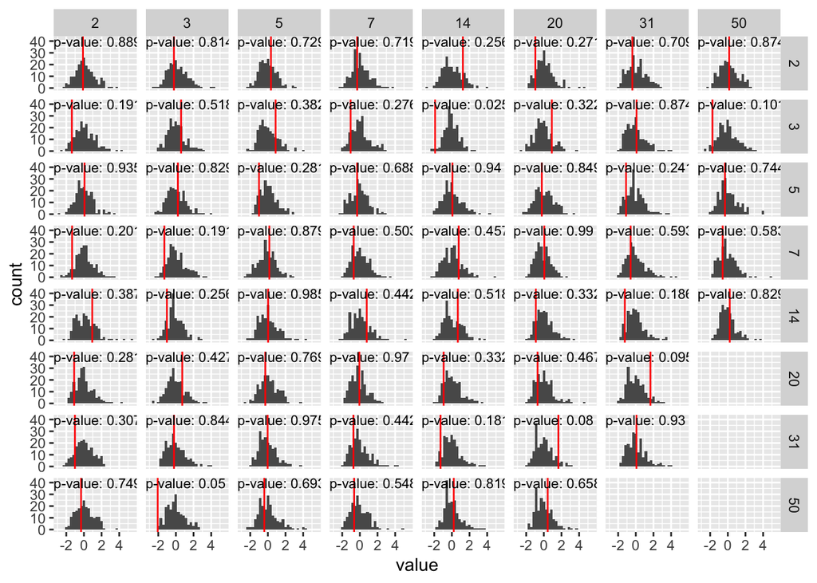

```r
data_N01 <- read_rds(here("simulations/norm/null_design_quantrans_nperm/data-agg/all_data_wpd_N01.rds"))

data_N01_obs <- data_N01 %>% filter(perm_id==1)
data_N01_samp <- data_N01 %>% filter(perm_id!=1)

#plot_mmpd_null_grid(data_N01_samp, data_N01_obs)

mmpd_dist_null_grid  = data_N01_samp

mmpd_null_orig = data_N01_obs
compute_p_value <- left_join(mmpd_dist_null_grid, mmpd_null_orig,
                               by = c("nx", "nfacet")) %>%
    group_by(nx, nfacet) %>%
    summarise(p_value = sum(if_else(abs(value.x)>abs(value.y),1,0))/n(), .groups = 'drop')

  ggplot() +
    geom_histogram(data = mmpd_dist_null_grid, aes(x = value))  +
    geom_vline(data = mmpd_null_orig, aes(xintercept = value),colour = "red") +
    geom_text(data = round(compute_p_value, 3), size = 3,
              aes(x = -Inf,
                  y =  Inf,
                  label = paste("p-value:",p_value),
                  hjust   = 0,
                  vjust   = 1)) +
    facet_grid(nx ~ nfacet)
```

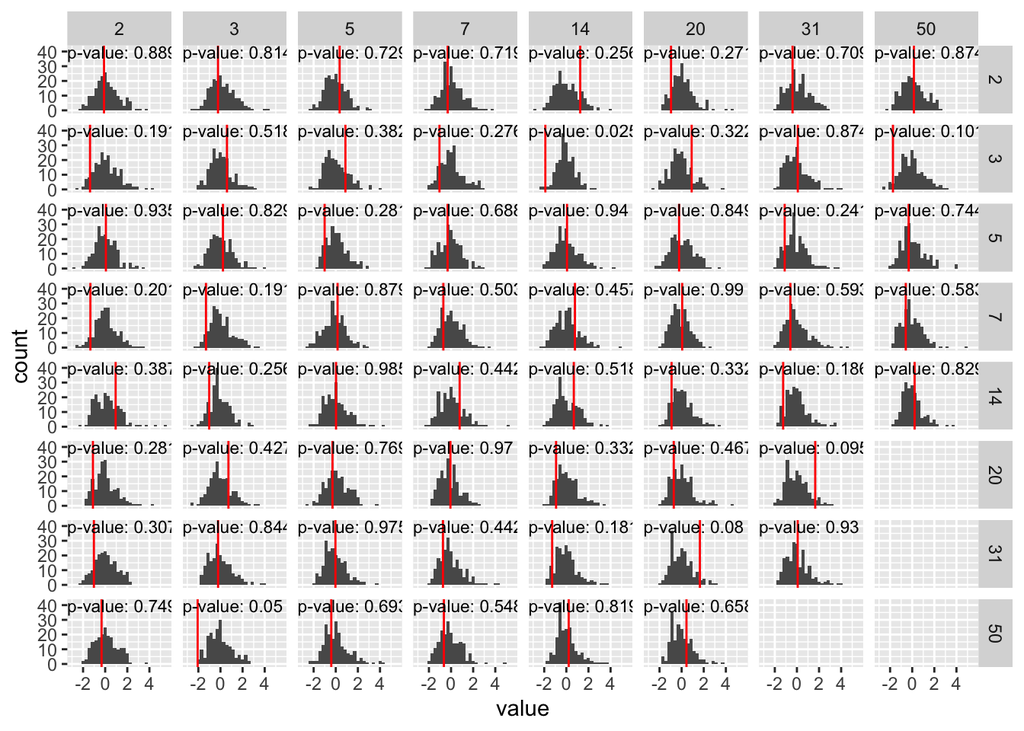

```r
library(readr)
library(tidyverse)
data_N01 <- read_rds(here("simulations/norm/null_design_quantrans_nperm/data-agg/all_data_wpd_N01.rds"))

data_N01_obs <- data_N01 %>% filter(perm_id==1)
data_N01_samp <- data_N01 %>% filter(perm_id!=1)

#plot_mmpd_null_grid(data_N01_samp, data_N01_obs)

mmpd_dist_null_grid  = data_N01_samp

mmpd_null_orig = data_N01_obs
compute_p_value <- left_join(mmpd_dist_null_grid, mmpd_null_orig,
                               by = c("nx", "nfacet")) %>%
    group_by(nx, nfacet) %>%
    summarise(p_value = sum(if_else(abs(value.x)>abs(value.y),1,0))/n(), .groups = 'drop')

  ggplot() +
    geom_histogram(data = mmpd_dist_null_grid, aes(x = value))  +
    geom_vline(data = mmpd_null_orig, aes(xintercept = value),colour = "red") +
    geom_text(data = round(compute_p_value, 3), size = 3,
              aes(x = -Inf,
                  y =  Inf,
                  label = paste("p-value:",p_value),
                  hjust   = 0,
                  vjust   = 1)) +
    facet_grid(nx ~ nfacet)
```

```r
sim_varall_normal <- function(nx, nfacet, mean, sd, w) {
  dist_normal((mean + seq(0,
    (nx *
      nfacet - 1),
    by = 1
  ) * w), sd)
}
sim_panel_varall <- sim_panel(
  nx = 2, nfacet = 3,
  ntimes = 500,
  sim_dist = sim_varall_normal(2, 3, 0, 1, 10)
) %>% unnest(data)

set.seed(9999)
varall <- compute_pairwise_norm(sim_panel_varall,
                           gran_x = "id_x",
                           gran_facet = "id_facet",
                           response = sim_data,
                           nperm = 200
)
```

```r
# plot
p_varall <- sim_panel_varall %>%
  ggplot(aes(x = as.factor(id_x), y = sim_data)) + facet_wrap(~id_facet) + geom_boxplot()
```

```r
sim_varx_normal <- function(nx, nfacet, mean, sd, w) {
   rep(dist_normal((mean + seq(0, nx - 1, by = 1) * w), sd), nfacet)
 }

sim_panel_varx <- sim_panel(
   nx = 2, nfacet = 3,
   ntimes = 5,
   sim_dist = sim_varx_normal(2, 3, 0, 1, 10)
 ) %>% unnest(data)


set.seed(9999)
varx <- compute_pairwise_norm(sim_panel_varx,
                           gran_x = "id_x",
                           gran_facet = "id_facet",
                           response = sim_data,
                           nperm = 200
)

# plot
p_varx <- sim_panel_varx %>%
  ggplot(aes(x = as.factor(id_x), y = sim_data)) + facet_wrap(~id_facet) + geom_boxplot()
```

```r
sim_varf_normal <- function(nx, nfacet, mean, sd, w) {
  rep(dist_normal((mean + seq(0, nfacet - 1, by = 1) * w), sd), each = nx)
}
sim_panel_varf <- sim_panel(
  nx = 2, nfacet = 3,
  ntimes = 5,
  sim_dist = sim_varf_normal(2, 3, 0, 1, 10)
) %>% unnest(data)


set.seed(9999)
varf <- compute_pairwise_norm(sim_panel_varf,
                           gran_x = "id_x",
                           gran_facet = "id_facet",
                           response = sim_data,
                           nperm = 200
)

p_varf <- sim_panel_varf %>%
  ggplot(aes(x = as.factor(id_x), y = sim_data)) + facet_wrap(~id_facet) + geom_boxplot()
```

```r
sim_panel_null <- sim_panel(
   nx = 2,
   nfacet = 3,
   ntimes = 500,
   sim_dist = distributional
   ::dist_normal(0, 1)
) %>% unnest(c(data))

set.seed(9999)

null <- compute_pairwise_norm(sim_panel_null,
                           gran_x = "id_x",
                           gran_facet = "id_facet",
                           response = sim_data,
                           nperm = 200
)

p_null <- sim_panel_null %>%
  ggplot(aes(x = as.factor(id_x), y = sim_data)) + facet_wrap(~id_facet) + geom_boxplot()
```